# How Does Climate Change Exacerbate Toxin Accumulation in Southern Resident Killer Whale Populations?

# 7 Figures + Interpreations

### 7.0.1 Figure 1b: Simulated Chinook Prey Availability Under Climate Scenarios

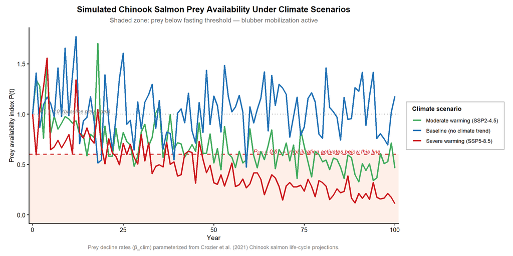

```r
# Simulate prey trajectories for each scenario (same seed as toxin sims)
set.seed(42)
prey_data <- scenarios %>% #sim prey avaliable
  rowwise() %>%
  mutate(
    prey_sim = list({
      prey <- numeric(n_years + 1)
      prey[1] <- P0
      for (yr in seq_len(n_years)) {
        log_P_mean <- log(P0) + beta_clim * yr
        prey[yr + 1] <- exp(rnorm(1, mean = log_P_mean, sd = sigma_P))
      }
      tibble(year = 0:n_years, prey = prey)
    })
  ) %>%
  ungroup() %>%
  unnest(prey_sim)

#plot it
ggplot(prey_data, aes(x = year, y = prey, colour = label)) +
  # Shade the fasting zone (below P_min)
  annotate("rect", xmin = -Inf, xmax = Inf, ymin = -Inf, ymax = P_min,
           fill = "#fee0d2", alpha = 0.5) +
  # Fasting threshold line
  geom_hline(yintercept = P_min, linetype = "dashed",
             colour = "#cb181d", linewidth = 0.8) +
  annotate("text", x = 96, y = P_min + 0.03,
           label = paste0("P\u2098\u1d62\u2099 = ", P_min, "  \u2192  mobilization activates below this line"),
           hjust = 1, size = 3.3, colour = "#cb181d", fontface = "italic") +
  # Prey lines
  geom_line(linewidth = 1.2) +
  # Baseline P0 reference
  geom_hline(yintercept = P0, linetype = "dotted",
             colour = "grey60", linewidth = 0.6) +
  annotate("text", x = 2, y = P0 + 0.03,
           label = "P\u2080 = 1.0  (baseline prey index)",
           hjust = 0, size = 3.0, colour = "grey50", fontface = "italic") +
  scale_colour_manual(
    values = c(
      "No trend (baseline)"  = "#2171b5",
      "Moderate (SSP2-4.5)"  = "#41ab5d",
      "Severe (SSP5-8.5)"    = "#cb181d"
    ),
    labels = c(
      "No trend (baseline)"  = "Baseline (no climate trend)",
      "Moderate (SSP2-4.5)"  = "Moderate warming (SSP2-4.5)",
      "Severe (SSP5-8.5)"    = "Severe warming (SSP5-8.5)"
    )
  ) +
  scale_x_continuous(expand = c(0.01, 0)) +
  scale_y_continuous(limits = c(0, NA)) +
  labs(
    title    = "Simulated Chinook Salmon Prey Availability Under Climate Scenarios",
    subtitle = "Shaded zone: prey below fasting threshold \u2014 blubber mobilization active",
    x        = "Year",
    y        = "Prey availability index P(t)",
    colour   = "Climate scenario",
    caption  = "Prey decline rates (\u03b2_clim) parameterized from Crozier et al. (2021) Chinook salmon life-cycle projections."
  ) +
  theme_classic(base_size = 13) +
theme(
  plot.title    = element_text(face = "bold", hjust = 0.5, size = 14),
  plot.subtitle = element_text(hjust = 0.5, colour = "grey40", size = 11),
  plot.caption  = element_text(colour = "grey50", size = 9, hjust = 0.5),

  legend.position   = "right",
  legend.background = element_rect(fill = "white", colour = "grey70"),
  legend.margin     = margin(6, 10, 6, 10),
  legend.title      = element_text(face = "bold", size = 10),
  legend.text       = element_text(size = 9),

  axis.title.x = element_text(size = 11, hjust = 0.5),
  axis.title.y = element_text(size = 11, angle = 90),

  axis.text  = element_text(size = 10),

  plot.margin = margin(10, 15, 10, 15)
)
```

Interpretation: This figure shows how much **Chinook salmon prey** is available to Southern Resident Killer Whales (SRKWs) under each climate scenario. It provides the foundation for the patterns seen in Tables 1–3.

The **red dashed line (Pₘᵢₙ = 0.60)** is the key threshold. When prey falls below this level, whales cannot get enough energy from food and must **burn blubber for energy**. Burning blubber releases **stored PCBs into the bloodstream**, which is the toxin pathway studied in this project.

The three scenarios show very different prey patterns: **Baseline (blue):** Prey fluctuates around the long-term average (P₀ = 1.0) and only briefly drops below the threshold. This means fasting and PCB mobilization happen **rarely**. **Moderate warming (green):** Prey gradually declines and begins spending more time below the threshold after about **year 25**, meaning whales fast more often. **Severe warming (red):** Prey falls below the threshold early and stays there for most of the simulation, declining toward very low levels by **year 100**. This means whales face a **long-term energy deficit** and must burn blubber frequently.

This pattern helps explain the PCB results. Under the severe scenario, the long periods below the threshold lead to **repeated blubber burning**, which releases more stored PCBs. That is why PCB levels in Table 2 eventually **stop declining and begin rising again** under severe warming, while they continue to decline under the baseline and moderate scenarios.

Overall, the figure shows that **climate-driven prey decline increases PCB exposure through blubber mobilization**, and the effect becomes stronger the longer whales remain below the fasting threshold.

### 7.0.2 Figure 2: PCB Load in Reproductive Females

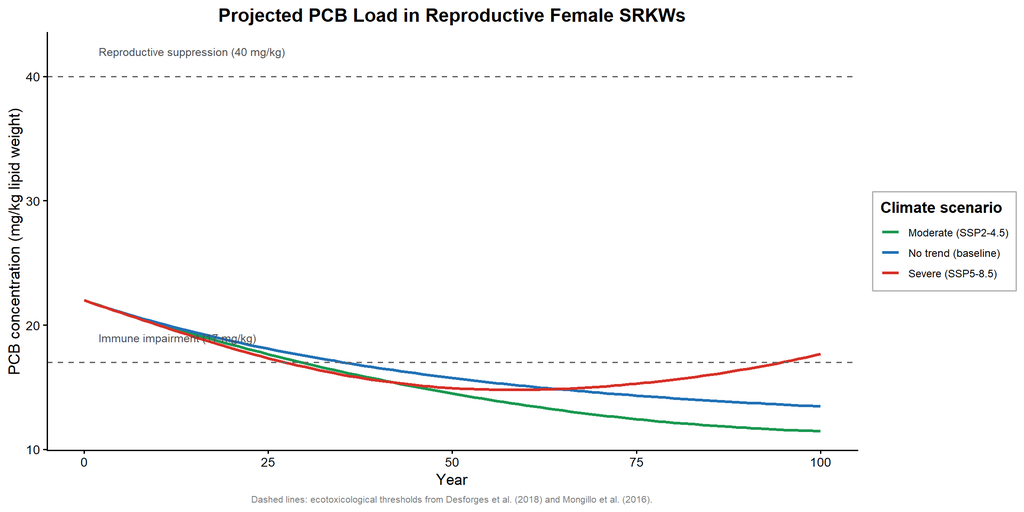

```r
# Figure 2
# Biological threshold reference lines
thresholds <- tibble(
  yintercept = c(17, 40),
  label      = c("Immune impairment (17 mg/kg)",
                 "Reproductive suppression (40 mg/kg)")
)

ggplot(results, aes(x = year, y = ReproFemales_median, colour = label)) +
  geom_line(linewidth = 1.1) +

  geom_hline(data = thresholds,
             aes(yintercept = yintercept),
             linetype = "dashed", colour = "grey40", linewidth = 0.7) +

  geom_text(data = thresholds,
            aes(x = 2, y = yintercept + 2, label = label),
            inherit.aes = FALSE,
            hjust = 0, size = 3.3, colour = "grey30") +

  scale_colour_manual(values = c("#1a9850", "#2171b5", "#d73027")) +

  labs(
    title    = "Projected PCB Load in Reproductive Female SRKWs",
    x        = "Year",
    y        = "PCB concentration (mg/kg lipid weight)",
    colour   = "Climate scenario",
    caption  = "Dashed lines: ecotoxicological thresholds from Desforges et al. (2018) and Mongillo et al. (2016)."
  ) +

  theme_classic(base_size = 13) +

  theme(
    # Center titles
    plot.title    = element_text(face = "bold", hjust = 0.5),
    plot.subtitle = element_text(colour = "grey40", hjust = 0.5),

    # Center axis titles
    axis.title.x = element_text(hjust = 0.5),
    axis.title.y = element_text(hjust = 0.5),

    # Legend on right in box
    legend.position   = "right",
    legend.background = element_rect(fill = "white", colour = "grey70"),
    legend.box.background = element_rect(colour = "grey70"),
    legend.title      = element_text(face = "bold"),
    legend.text       = element_text(size = 9),

    # Caption
    plot.caption = element_text(colour = "grey50", hjust = 0.5, size = 8)
  )
```

Interpretation: Figure 2 shows how PCB levels change in **reproductive females**, the most important life stage because they determine whether calves are born.

All three scenarios begin at about **22 mg/kg** and decline together early in the simulation. This happens because females pass some PCBs to their calves during reproduction, which lowers their own PCB levels.

**Severe warming (red):** This scenario behaves differently. PCB levels decline at first but **reverse around year 50–60 and begin rising again**, reaching about **17 mg/kg** by year 100. This increase happens because severe prey shortages force whales to burn stored fat more often, releasing PCBs from their blubber into their bodies.

This result supports the study’s hypothesis. The only difference between scenarios is the **rate of prey decline**, so the increase in PCB levels under the severe scenario shows that **climate-driven prey shortages can increase internal PCB exposure through blubber mobilization**.

Although PCB levels in reproductive females do not reach the **reproductive suppression threshold (40 mg/kg)** in this pilot simulation, the upward trend under severe warming shows that the mobilization pathway is real and detectable. The full model will test whether this increase is large enough to affect survival, reproduction, and long-term population decline.

### 7.0.3 Figure 3: All Four Life Stages

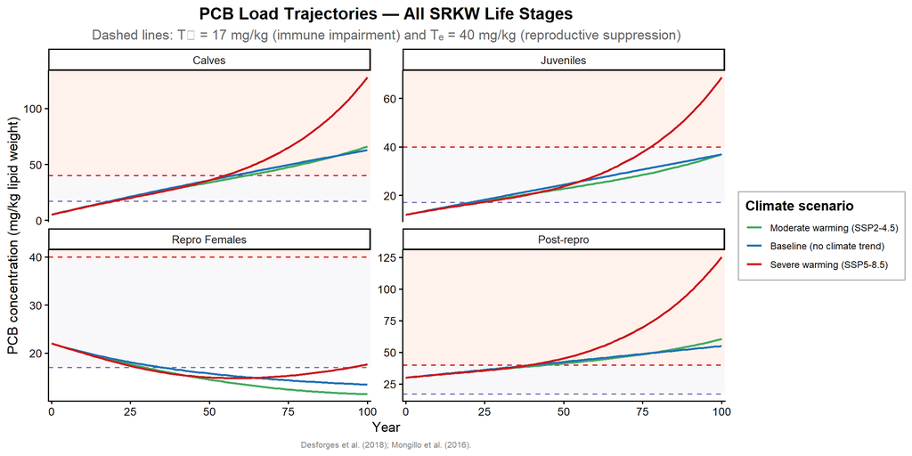

```r
results_long <- results %>%
  pivot_longer(
    cols      = c(Calves_median, Juveniles_median, ReproFemales_median, Postrepro_median),
    names_to  = "stage",
    values_to = "toxin_median"
  ) %>%
  mutate(stage = gsub("_median", "", stage)) %>%
  mutate(stage = recode(stage,
    "ReproFemales" = "Repro Females",
    "Postrepro"    = "Post-repro"
  )) %>%
  mutate(stage = factor(stage,
    levels = c("Calves", "Juveniles", "Repro Females", "Post-repro")))

ggplot(results_long, aes(x = year, y = toxin_median, colour = label)) +
  # Shaded risk zones (applied per facet)
  annotate("rect", xmin = -Inf, xmax = Inf, ymin = 40, ymax = Inf,
           fill = "#fee0d2", alpha = 0.45) +
  annotate("rect", xmin = -Inf, xmax = Inf, ymin = 17, ymax = 40,
           fill = "#efedf5", alpha = 0.45) +
  geom_hline(yintercept = 17, linetype = "dashed",
             colour = "#756bb1", linewidth = 0.6) +
  geom_hline(yintercept = 40, linetype = "dashed",
             colour = "#cb181d", linewidth = 0.6) +
  geom_line(linewidth = 1.0) +
  facet_wrap(~stage, scales = "free_y", nrow = 2) +
  scale_colour_manual(
    values = c(
      "No trend (baseline)"  = "#2171b5",
      "Moderate (SSP2-4.5)"  = "#41ab5d",
      "Severe (SSP5-8.5)"    = "#cb181d"
    ),
    labels = c(
      "No trend (baseline)"  = "Baseline (no climate trend)",
      "Moderate (SSP2-4.5)"  = "Moderate warming (SSP2-4.5)",
      "Severe (SSP5-8.5)"    = "Severe warming (SSP5-8.5)"
    )
  ) +
  scale_x_continuous(expand = c(0.01, 0)) +
  labs(
    title   = "PCB Load Trajectories \u2014 All SRKW Life Stages",
    subtitle = "Dashed lines: T\u209b = 17 mg/kg (immune impairment) and T\u2091 = 40 mg/kg (reproductive suppression)",
    x       = "Year",
    y       = "PCB concentration (mg/kg lipid weight)",
    colour  = "Climate scenario",
    caption = "Desforges et al. (2018); Mongillo et al. (2016)."
  ) +
  theme_classic(base_size = 13) +

    theme(
    # Center titles
      plot.title    = element_text(face = "bold", hjust = 0.5),
      plot.subtitle = element_text(colour = "grey40", hjust = 0.5),

    # Center axis titles
      axis.title.x = element_text(hjust = 0.5),
      axis.title.y = element_text(hjust = 0.5),

    # Legend on right in box
      legend.position   = "right",
      legend.background = element_rect(fill = "white", colour = "grey70"),
      legend.box.background = element_rect(colour = "grey70"),
      legend.title      = element_text(face = "bold"),
      legend.text       = element_text(size = 9),

    # Caption
      plot.caption = element_text(colour = "grey50", hjust = 0.5, size = 8)
    )
```

The key result is that **calves and juveniles exceed the thresholds even though reproductive females do not**. This means PCB exposure is likely to reduce **calf and juvenile survival** before it affects reproduction in adult females. If young whales die faster than they can mature into adults, the population will decline even if reproduction is still possible.

Overall, this suggests the **blubber-mobilization pathway may drive population decline through reduced survival of young whales before it affects reproduction**, making it an early warning signal of population collapse.

# 8 Results

The research question: **Does climate-driven Chinook salmon decline increase PCB exposure in Southern Resident Killer Whales (SRKWs) through blubber mobilization, and how strong must prey decline be for this toxin feedback to increase extinction risk?**

**PCB levels respond differently depending on climate severity.** Reproductive females begin the simulation at about **22 mg/kg** PCB concentration (Figure 2). Under the baseline and moderate scenarios, PCB levels steadily decline because females transfer contaminants to calves and dietary intake decreases. By year 100, PCB levels fall to about **13.5 mg/kg** in the baseline and **11.5 mg/kg** in the moderate scenario. The severe scenario behaves differently. PCB levels initially decline but begin **rising again around years 60–65**, reaching about **17.7 mg/kg** by year 100. This increase occurs because repeated fasting releases PCBs from stored fat faster than mothers can eliminate them through reproduction. This shows that **severe prey decline can reverse the downward trend in PCB exposure.**

**Young whales are most affected.** Figure 3 shows that calves and juveniles accumulate much higher PCB levels under the severe scenario. By year 100, calves reach about **125 mg/kg** and juveniles about **65 mg/kg**, far above known biological thresholds. These high levels occur because calves receive PCBs both from their mothers and from contaminated prey. This matters for population dynamics because PCB exposure reduces **survival of calves and juveniles** before it affects reproduction in adult females. If too many young whales die before reaching adulthood, the population will decline even if adult reproduction remains possible.

**Population decline in the pilot simulation mainly reflects background trends.** Across all scenarios, the number of reproductive females declines steadily, and all simulations reach quasi-extinction by year 50. This happens because the model assumes baseline demographic rates already below replacement ($\lambda < 1$). As a result, the pilot simulation cannot yet separate the effect of climate-driven toxin exposure from the population’s existing decline.

# 9 Summary

These results demonstrate that extreme prey scarcity does not just starve the whales; it actively re poisons them by releasing sequestered toxins back into the bloodstream. The full coupled model will further test the extent to which this toxin feedback loop accelerates extinction risk

# 10 References

Abdul-Aziz, O. I., Mantua, N. J., & Myers, K. W. (2011). Potential climate change impacts on thermal habitats of Pacific salmon (*Oncorhynchus* spp.) in the North Pacific Ocean and adjacent seas. *Canadian Journal of Fisheries and Aquatic Sciences*, 68(10), 1660–1680. https://doi.org/10.1139/f2011-090

Atlas, W. I., Sloat, M. R., Satterthwaite, W. H., Buehrens, T. W., Parken, C. K., Moore, J. W., … & Potapova, A. (2023). Trends in Chinook salmon spawner abundance and total run size highlight linkages between life history, geography and decline. *Fish and Fisheries*, 24(4), 595–617. https://doi.org/10.1111/faf.12746

Crozier, L. G., McClure, M. M., Beechie, T., Bograd, S. J., Boughton, D. A., Carr, M., … & Zabel, R. W. (2021). Climate change threatens Chinook salmon throughout their life cycle. *Communications Biology*, 4, 222. https://doi.org/10.1038/s42003-021-01734-w

Desforges, J.-P., Hall, A., McConnell, B., Rosing-Asvid, A., Barber, J. L., Brownlow, A., … & Dietz, R. (2018). Predicting global killer whale population collapse from PCB pollution. *Science*, 361(6409), 1373–1376. https://doi.org/10.1126/science.aat1953

Ford, J. K. B., Ellis, G. M., Olesiuk, P. F., & Balcomb, K. C. (2010). Linking killer whale survival and prey abundance: food limitation in the oceans’ apex predator? *Biology Letters*, 6(1), 139–142. https://doi.org/10.1098/rsbl.2009.0468

Marine Mammal Commission. (2020). *Southern Resident Killer Whale*. U.S. Marine Mammal Commission Species Overview. https://www.mmc.gov/priority-topics/species-of-concern/southern-resident-killer-whale/

Mongillo, T. M., Ylitalo, G. M., Rhodes, L. D., O’Neill, S. M., Noren, D. P., & Hanson, M. B. (2016). *Exposure to a mixture of toxic chemicals: implications for the health of endangered Southern Resident killer whales* (NOAA Technical Memorandum NMFS-NWFSC-135). U.S. Department of Commerce. https://doi.org/10.7289/V5/TM-NWFSC-135

Olesiuk, P. F., Bigg, M. A., & Ellis, G. M. (1990). Life history and population dynamics of resident killer whales (*Orcinus orca*) in the coastal waters of British Columbia and Washington State. *Report of the International Whaling Commission, Special Issue 12*, 209–243.

Ward, E. J., Holmes, E. E., & Balcomb, K. C. (2009). Quantifying the effects of prey availability on killer whale (*Orcinus orca*) reproductive success. *Journal of Applied Ecology*, 46(3), 632–640. https://doi.org/10.1111/j.1365-2664.2009.01647.x

Williams, R., Lacy, R. C., Ashe, E., Barrett-Lennard, L., Brown, T. M., Gaydos, J. K., … & Paquet, P. (2024). Warning sign of an accelerating decline in critically endangered killer whales (*Orcinus orca*). *Communications Earth & Environment*, 5, 173. https://doi.org/10.1038/s43247-024-01327-5